# KNN

Wei

8/21/2020

## K-Nearest Neighbours

KNN is used to classify unlabelled items based on **feature similarities** with **K Nearest Neighbours**.

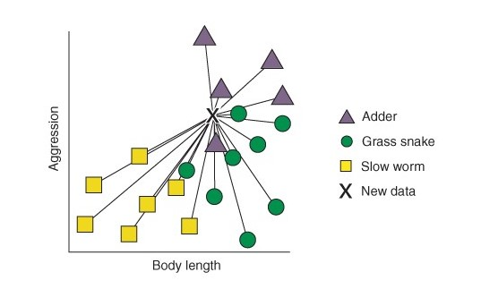

KNN illustration from Hefin Rhys

Procedures of CNN:

1. Select the features
2. KNN algorithm calculates the **distance (based on the features)** between the unlabelled and all labelled cases
3. Select the nearest K candidates based on the distance
4. Let the K candidates vote

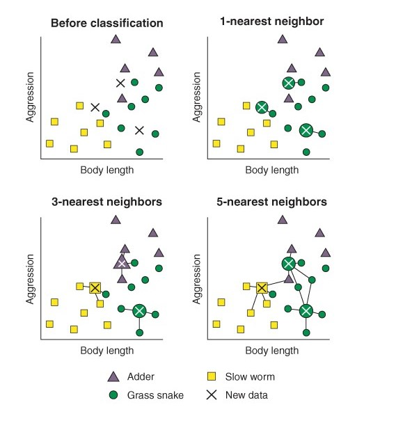

KNN Algorithm

## Explore The Data

```r
data(diabetes, package = "mclust")
diabetesTib <- as_tibble(diabetes)
summary(diabetesTib)
```

```
##       class       glucose       insulin            sspg
##  Chemical:36   Min.   : 70   Min.   :  45.0   Min.   : 10.0
##  Normal  :76   1st Qu.: 90   1st Qu.: 352.0   1st Qu.:118.0
##  Overt   :33   Median : 97   Median : 403.0   Median :156.0
##                Mean   :122   Mean   : 540.8   Mean   :186.1
##                3rd Qu.:112   3rd Qu.: 558.0   3rd Qu.:221.0
##                Max.   :353   Max.   :1568.0   Max.   :748.0
```

```r
head(diabetesTib)
```

```
## # A tibble: 6 x 4
##   class  glucose insulin  sspg
##   <fct>    <dbl>   <dbl> <dbl>
## 1 Normal      80     356   124
## 2 Normal      97     289   117
## 3 Normal     105     319   143
## 4 Normal      90     356   199
## 5 Normal      90     323   240
## 6 Normal      86     381   157
```

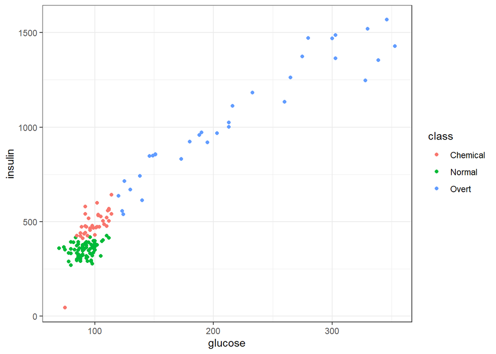

```r
ggplot(diabetesTib, aes(glucose, insulin, col = class)) + geom_point() + theme_bw()
```

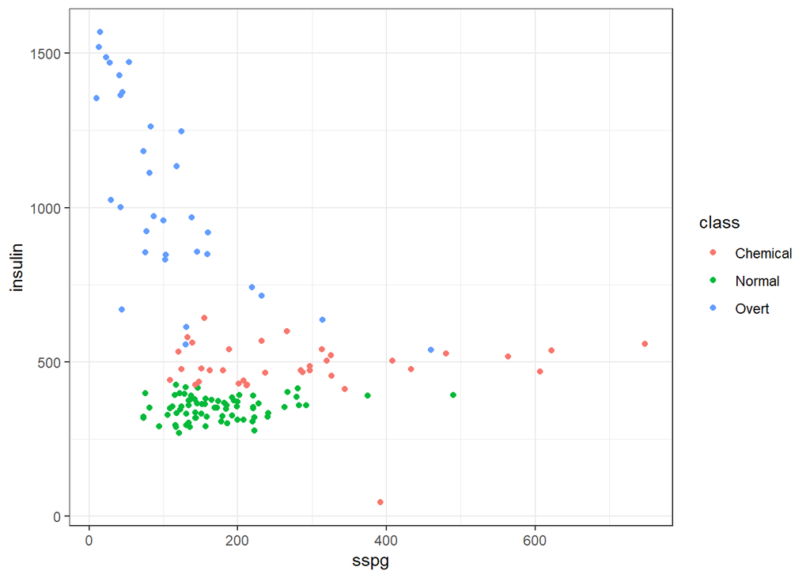

```r
ggplot(diabetesTib, aes(sspg, insulin, col = class)) + geom_point() + theme_bw()
```

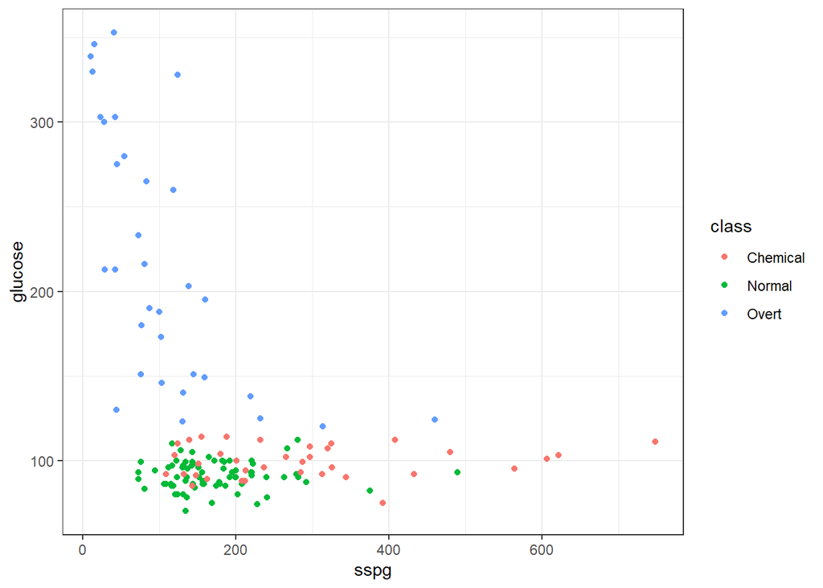

```r
ggplot(diabetesTib, aes(sspg, glucose, col = class)) + geom_point() + theme_bw()
```

## Using “mlr” package to train the kNN model

It is important to standardize the predictor variables in the machine learning algorithms. The kNN algorithm wrapped in the mlr package has done this for users.

Building a machine learning model with mlr package in three stages:

1. **Define the task**: specify the predictors and outcomes
2. **Define the learner**: the name of the algorithm to use (with additional parameters)
3. **Train the model**: pass the task(data) to the learner

### Step 1: Define the task – the outcome and the predictors

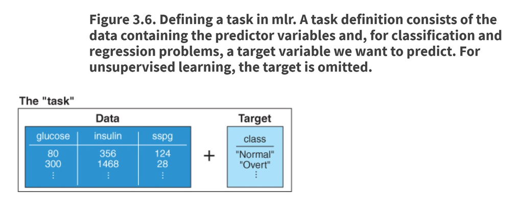

```r
diabetesTask <- makeClassifTask(data = diabetesTib, target = "class")
diabetesTask
```

```
## Supervised task: diabetesTib
## Type: classif
## Target: class
## Observations: 145
## Features:
##    numerics     factors     ordered functionals
##           3           0           0           0
## Missings: FALSE
## Has weights: FALSE
## Has blocking: FALSE
## Has coordinates: FALSE
## Classes: 3
## Chemical   Normal    Overt
##       36       76       33
## Positive class: NA
```

### Step 2: Define the learner – algorithm

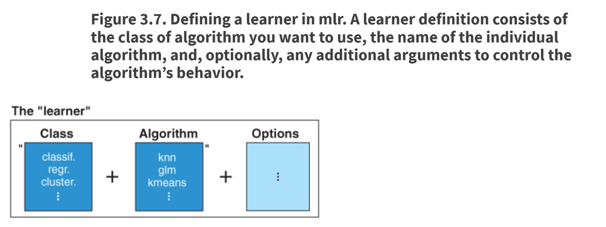

```r
knn <- makeLearner("classif.knn", par.vals = list("k" = 2))
```

We can also use `listLearners("classif")$class` to list all available learners.

### Step 3: Train the model

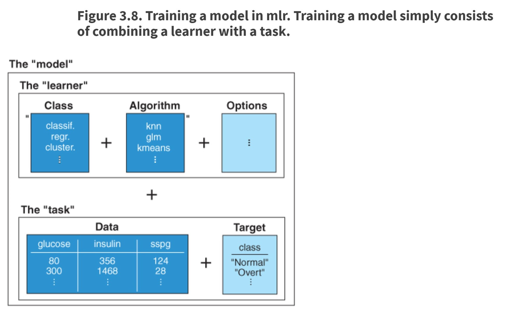

```r
knnModel <- train(knn, diabetesTask)
```

### Model Assessment – Performance

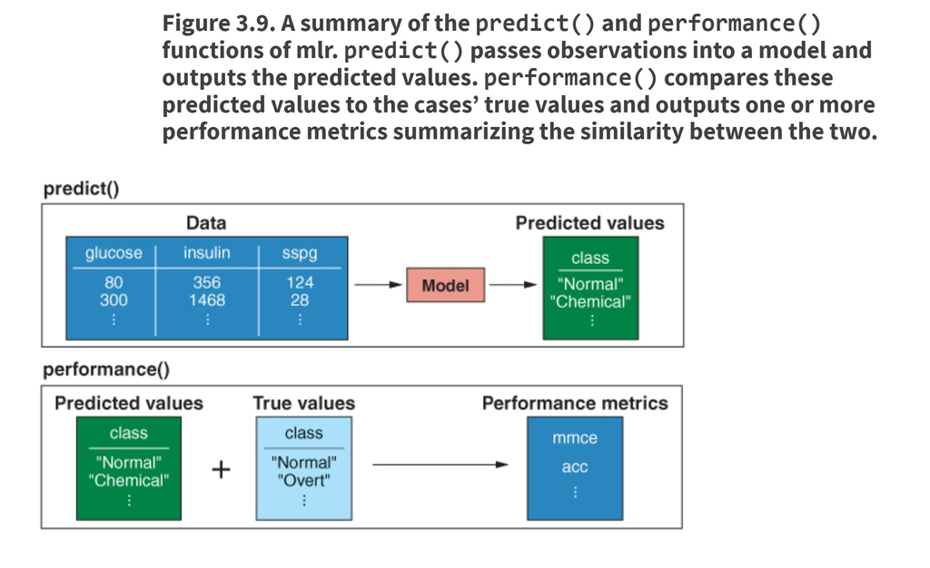

The predicted valuea is then compared to the true label based on the measure we select. The measure can be *mmce*, mean misclassification error, or *acc*, accurancy.

```r
knnPred <- predict(knnModel, newdata = diabetesTib)
knnPred
```

```
## Prediction: 145 observations
## predict.type: response
## threshold:
## time: 0.00
##    truth response
## 1 Normal   Normal
## 2 Normal   Normal
## 3 Normal   Normal
## 4 Normal   Normal
## 5 Normal   Normal
## 6 Normal   Normal
## ... (#rows: 145, #cols: 2)
```

```r
performance(knnPred, measures = list(mmce, acc))
```

```
##       mmce        acc
## 0.06206897 0.93793103
```